# NBA Injuries EDA

The following document analyzes player injuries in the NBA from the years 2010 to 2020. A point of contention in the NBA is how often players are rested when they may or may not even be injuried. This analysis looks at both injuries and rest in the context of missed games. The data was pulled from Kaggle.

**Data Source:**

- injuries_2010-2020.csv

**Below is a list of variables that were of importance:**

- date
- team
- acquired
- notes

#### Importing relevant libraries

```python
import pandas as pd
import numpy as np
import matplotlib as mpl
import seaborn as sb
import missingno as msno
import matplotlib.pyplot as plt
```

#### Reading in the data set

```python
nba_injuries = pd.read_csv('/Users/omkar/Downloads/injuries_2010-2020.csv')
```

#### Viewing data set

```python
nba_injuries
```

|  | Date | Team | Acquired | Relinquished | Notes |
| --- | --- | --- | --- | --- | --- |
| 0 | 2010-10-03 | Bulls | NaN | Carlos Boozer | fractured bone in right pinky finger (out inde... |
| 1 | 2010-10-06 | Pistons | NaN | Jonas Jerebko | torn right Achilles tendon (out indefinitely) |
| 2 | 2010-10-06 | Pistons | NaN | Terrico White | broken fifth metatarsal in right foot (out ind... |
| 3 | 2010-10-08 | Blazers | NaN | Jeff Ayres | torn ACL in right knee (out indefinitely) |
| 4 | 2010-10-08 | Nets | NaN | Troy Murphy | strained lower back (out indefinitely) |
| ... | ... | ... | ... | ... | ... |
| 27100 | 2020-09-30 | Lakers | Dion Waiters | NaN | activated from IL |
| 27101 | 2020-10-02 | Heat | NaN | Bam Adebayo | strained neck (DTD) |
| 27102 | 2020-10-02 | Heat | NaN | Goran Dragic | placed on IL with torn plantar fascia in left ... |
| 27103 | 2020-10-02 | Heat | Chris Silva | NaN | activated from IL |
| 27104 | 2020-10-06 | Heat | Bam Adebayo | NaN | returned to lineup |

27105 rows × 5 columns

#### Visualizing missing values in each dataset

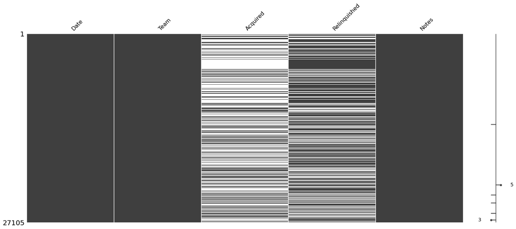

```python
msno.matrix(nba_injuries)
```

From this we can observe that the 'Acquired' column has the most null values, followed by the 'Relinquished' column. Because the 'Acquired' column doesn't provide any value in regards to what is being provided by its respective value in the 'Notes' column, we will get rid of this column in the dataframe.

#### Getting rid of 'Acquired' values since it isn't related to getting injured or resting

```python
del nba_injuries['Acquired']
nba_injuries
```

|  | Date | Team | Relinquished | Notes |
| --- | --- | --- | --- | --- |
| 0 | 2010-10-03 | Bulls | Carlos Boozer | fractured bone in right pinky finger (out inde... |
| 1 | 2010-10-06 | Pistons | Jonas Jerebko | torn right Achilles tendon (out indefinitely) |
| 2 | 2010-10-06 | Pistons | Terrico White | broken fifth metatarsal in right foot (out ind... |
| 3 | 2010-10-08 | Blazers | Jeff Ayres | torn ACL in right knee (out indefinitely) |
| 4 | 2010-10-08 | Nets | Troy Murphy | strained lower back (out indefinitely) |
| ... | ... | ... | ... | ... |
| 27100 | 2020-09-30 | Lakers | NaN | activated from IL |
| 27101 | 2020-10-02 | Heat | Bam Adebayo | strained neck (DTD) |
| 27102 | 2020-10-02 | Heat | Goran Dragic | placed on IL with torn plantar fascia in left ... |
| 27103 | 2020-10-02 | Heat | NaN | activated from IL |
| 27104 | 2020-10-06 | Heat | NaN | returned to lineup |

27105 rows × 4 columns

#### Getting rid of NA values in data set

```python
nba_injuries.dropna()
```

|  | Date | Team | Relinquished | Notes |
| --- | --- | --- | --- | --- |
| 0 | 2010-10-03 | Bulls | Carlos Boozer | fractured bone in right pinky finger (out inde... |
| 1 | 2010-10-06 | Pistons | Jonas Jerebko | torn right Achilles tendon (out indefinitely) |
| 2 | 2010-10-06 | Pistons | Terrico White | broken fifth metatarsal in right foot (out ind... |
| 3 | 2010-10-08 | Blazers | Jeff Ayres | torn ACL in right knee (out indefinitely) |
| 4 | 2010-10-08 | Nets | Troy Murphy | strained lower back (out indefinitely) |
| ... | ... | ... | ... | ... |
| 27097 | 2020-09-22 | Celtics | Romeo Langford | surgery on right wrist (out for season) |
| 27098 | 2020-09-23 | Heat | Gabe Vincent | sore right knee (DTD) |
| 27099 | 2020-09-30 | Heat | Bam Adebayo | strained left shoulder (DTD) |
| 27101 | 2020-10-02 | Heat | Bam Adebayo | strained neck (DTD) |
| 27102 | 2020-10-02 | Heat | Goran Dragic | placed on IL with torn plantar fascia in left ... |

17558 rows × 4 columns

#### Counting the values in 'Notes' column to see what are the most common reasons for missing games

```python
nba_injuries.Notes.value_counts()[3:]
```

```
sprained left ankle (DNP)                                      362
rest (DTD)                                                     286
placed on IL with illness                                      274
placed on IL with sprained left ankle                          230
illness (DTD)                                                  228
                                                              ...
surgery to repair fractured orbital bone (out indefinitely)      1
sprained left ankle (P) / knee (CBC) (DNP)                       1
fractured left cheekbone (DNP)                                   1
placed on IL with hip injury (P)                                 1
placed on IL with strained right adductor (out for season)       1
Name: Notes, Length: 3111, dtype: int64
```

Doing a basic overlook we can see that 'sprained left ankle' was the most commonly listed injury with 'rest' following it at 286 occurences.

#### Visualizing the percentage of games that are missed because of being injured vs rest

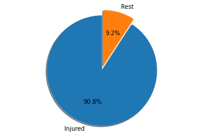

```python
length = len(nba_injuries.Notes.unique()) - 3
actual_injuries = ((length-286)/length)*100
rest_injuries = (286/length)*100
injuries_ratio = [actual_injuries, rest_injuries]
labels = 'Injured', 'Rest'
explode = (0, 0.1,)

fig1, ax1 = plt.subplots()
ax1.pie(injuries_ratio, explode=explode, labels=labels, autopct='%1.1f%%',
        shadow=True, startangle=90)
ax1.axis('equal')  # Equal aspect ratio ensures that pie is drawn as a circle.

plt.show()
```

#### Changing 'Date' column to datetime format

```python
nba_injuries['Date'] = pd.to_datetime(nba_injuries['Date'])
```

```python
nba_injuries
```

|  | Date | Team | Relinquished | Notes |
| --- | --- | --- | --- | --- |
| 0 | 2010-10-03 | Bulls | Carlos Boozer | fractured bone in right pinky finger (out inde... |
| 1 | 2010-10-06 | Pistons | Jonas Jerebko | torn right Achilles tendon (out indefinitely) |
| 2 | 2010-10-06 | Pistons | Terrico White | broken fifth metatarsal in right foot (out ind... |
| 3 | 2010-10-08 | Blazers | Jeff Ayres | torn ACL in right knee (out indefinitely) |
| 4 | 2010-10-08 | Nets | Troy Murphy | strained lower back (out indefinitely) |
| ... | ... | ... | ... | ... |
| 27100 | 2020-09-30 | Lakers | NaN | activated from IL |
| 27101 | 2020-10-02 | Heat | Bam Adebayo | strained neck (DTD) |
| 27102 | 2020-10-02 | Heat | Goran Dragic | placed on IL with torn plantar fascia in left ... |
| 27103 | 2020-10-02 | Heat | NaN | activated from IL |
| 27104 | 2020-10-06 | Heat | NaN | returned to lineup |

27105 rows × 4 columns

#### Counting the values in 'Date' column to see which dates had the most games missed

```python
nba_injuries.Date.value_counts()
```

```
2014-04-16    76
2012-04-26    75
2017-04-12    74
2017-10-18    67
2011-04-13    67
              ..
2016-06-30     1
2016-06-29     1
2016-06-15     1
2016-06-05     1
2020-10-06     1
Name: Date, Length: 2103, dtype: int64
```

#### Creating a table of the games missed due to rest reasons

```python
index_of_rest = nba_injuries.loc[nba_injuries['Notes'].str.startswith('rest'), 'Notes'].index.tolist()
nba_injuries.iloc[index_of_rest]
```

|  | Date | Team | Relinquished | Notes |
| --- | --- | --- | --- | --- |
| 2333 | 2011-04-06 | Mavericks | Jason Kidd | rest (DNP) |
| 2425 | 2011-04-11 | Celtics | Paul Pierce | rest (DNP) |
| 2427 | 2011-04-11 | Celtics | Ray Allen | rest (DNP) |
| 2449 | 2011-04-11 | Pistons | Tracy McGrady | rest (DNP) |
| 2467 | 2011-04-12 | Grizzlies | Tony Allen | rest (DNP) |
| ... | ... | ... | ... | ... |
| 21913 | 2018-04-01 | Wizards | John Wall | rest (DTD) |
| 21943 | 2018-04-03 | Rockets | Trevor Ariza | rest (DTD) |
| 22022 | 2018-04-06 | Mavericks | Salah Mejri | rest / knee injury (out for season) |
| 22148 | 2018-04-11 | Rockets | Chris Paul | rest (DTD) |
| 22151 | 2018-04-11 | Rockets | James Harden | rest (DTD) |

440 rows × 4 columns

#### Visualizing the average number of players who rested per year

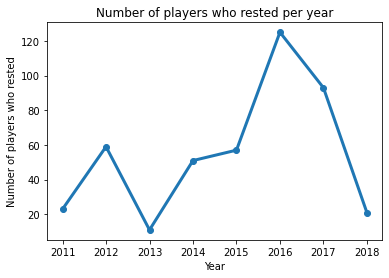

```python
group_year = nba_injuries.iloc[index_of_rest].groupby(nba_injuries.Date.dt.year)['Notes']
group_year.count()
plt.plot(group_year.count(), linewidth=3, marker='o')
plt.title('Number of players who rested per year')
plt.xlabel('Year')
plt.ylabel('Number of players who rested')
```

#### Visualizing the average number of players who rested by month

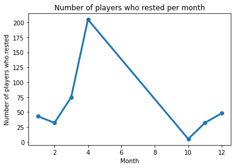

```python
group_month = nba_injuries.iloc[index_of_rest].groupby(nba_injuries.Date.dt.month)['Notes']
group_month.count()
plt.plot(group_month.count(), linewidth=3, marker='o')
plt.title('Number of players who rested per month')
plt.xlabel('Month')
plt.ylabel('Number of players who rested')
```

From this graph we can get a better sense as to when a majority of players are taking their rest. We can see an upward trend from the start of the season (October) to right before the playoffs (April) in the number of players who rest per month. This makes sense as more star players begin to rest before the Playoffs in order to stay healthy for them. Early April/Late March makes sense as the peak of time in which players would rest as this is right before the playoffs start. October also makes sense for being the month in which players rest the least as it is start/first month of the season.

#### Counting how many times players rested and saving it as a data frame in descending order

```python
players_rest = nba_injuries.iloc[index_of_rest].groupby(nba_injuries.Relinquished)['Notes']
players_rest = players_rest.count()
players_rest = players_rest.sort_values(ascending=False)[:10]
df= pd.DataFrame(players_rest)
```

#### Visualizing the nba players who rested the most games

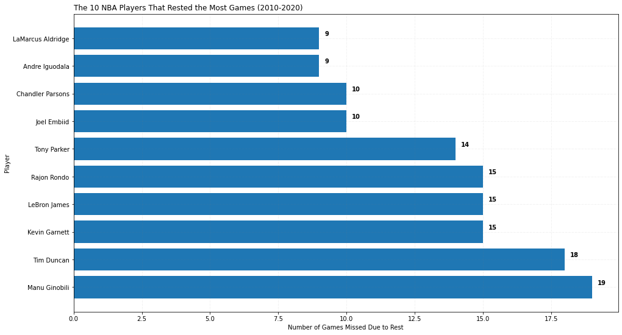

```python
fig, ax = plt.subplots(figsize =(16, 9))
ax.barh(df.index, df['Notes'])
ax.grid(b = True, color ='grey',
        linestyle ='-.', linewidth = 0.5,
        alpha = 0.2)
for i in ax.patches:
    plt.text(i.get_width()+0.2, i.get_y()+0.5,
             str(round((i.get_width()), 2)),
             fontsize = 10, fontweight ='bold',
             color ='black')

    ax.set_title('The 10 NBA Players That Rested the Most Games (2010-2020)',
             loc ='left', )
    plt.xlabel('Number of Games Missed Due to Rest')
    plt.ylabel('Player')
```

#### Counting how many times teams rested players and saving it as a data frame in descending order

```python
teams_rest = nba_injuries.iloc[index_of_rest].groupby(nba_injuries.Team)['Notes']
teams_rest = teams_rest.count()
teams_rest = teams_rest.sort_values(ascending=False)[:10]
teams_rest = pd.DataFrame(teams_rest)
```

#### Visualizing the NBA teams who rested their players the most games

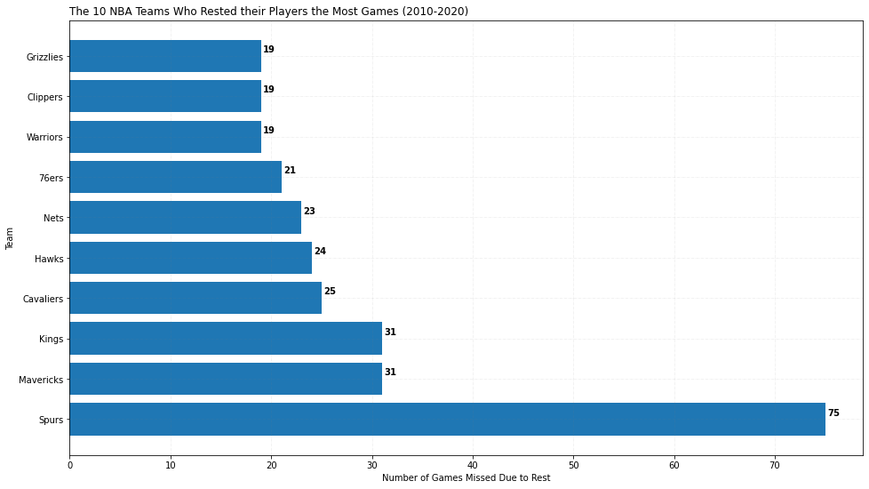

```python
fig, ax = plt.subplots(figsize =(16, 9))
ax.barh(teams_rest.index, teams_rest['Notes'])
ax.grid(b = True, color ='grey',
        linestyle ='-.', linewidth = 0.5,
        alpha = 0.2)
for i in ax.patches:
    plt.text(i.get_width()+0.2, i.get_y()+0.5,
             str(round((i.get_width()), 2)),
             fontsize = 10, fontweight ='bold',
             color ='black')

    ax.set_title('The 10 NBA Teams Who Rested their Players the Most Games (2010-2020)',
             loc ='left', )
    plt.xlabel('Number of Games Missed Due to Rest')
    plt.ylabel('Team')
```

#### Counting how many times teams have dealt with injuries

```python
nba_injuries_nr = nba_injuries.drop(index_of_rest)
nba_injuries_nr = nba_injuries_nr.dropna()
nba_injuries_nr = pd.DataFrame(nba_injuries_nr.groupby(nba_injuries.Team)['Notes'].count().sort_values(ascending=False))
```

#### Visualizing the number of injuries each team has dealt with (2010-2020)

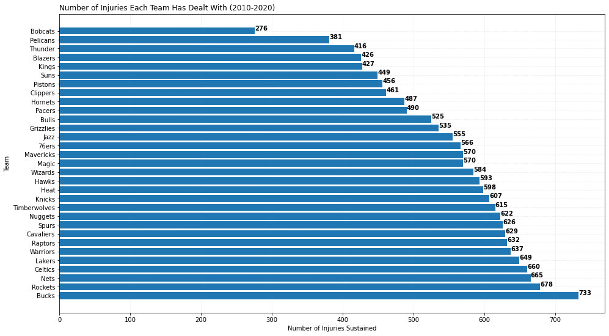

```python
fig, ax = plt.subplots(figsize =(16, 9))
ax.barh(nba_injuries_nr.index, nba_injuries_nr['Notes'])
ax.grid(b = True, color ='grey',
        linestyle ='-.', linewidth = 0.5,
        alpha = 0.2)
for i in ax.patches:
    plt.text(i.get_width()+0.2, i.get_y()+0.5,
             str(round((i.get_width()), 2)),
             fontsize = 10, fontweight ='bold',
             color ='black')

    ax.set_title('Number of Injuries Each Team Has Dealt With (2010-2020)',
             loc ='left', )
    plt.xlabel('Number of Injuries Sustained')
    plt.ylabel('Team')
```